# Attempt recruitment covariates in herring WHAM model

Sarah Gaichas

2024-09-17

# Introduction

Now that we have way too many copeopod time series, lets see if any of them are useful covariates in the Atlantic herring assessment model.

The primary target is a covariate on Atlamntic herring recruitment.

Adelle’s boosted regression tree model shows both spring large copepods and fall small copepods as important factors explaining recruitment patterns estimated by the WHAM model.

We have also developed a herring-larvae specific small copepod index within the area with more than the 70th percentile of cumulative 1982-2022 herring larvae density.

So we can try at least three flavors of copepod index as a model covariate.

# Methods

Installed multiWHAM from the `devel` branch: https://github.com/timjmiller/wham/tree/devel

`devtools::install_github("timjmiller/wham", dependencies=TRUE, ref="devel")`

Installation worked on the outdated mac os… so far.

Lets test the installation by seeing if I can get the same outputs as Jon did by running the model without any additions.

Modify Jon’s code from the Atlantic Herring RTWG google drive and now in this directory, `Example WHAM code to share.R` which sources his `WHAMfxns.R` and `hindcast.R` also now in this directory.

First run the base model and compare with the stored to ensure my installation is ok:

```r
#source some functions
source(here::here("WHAMfits/WHAMfxns.R"))
#source the hindcast function for MASE etc.
source(here::here("WHAMfits/hindcast.R"))

# starting with mm192, add suffix for different attempts
# test with no change

config <- "nochange"

# name the model directory
name <- paste0("mm192_", config)

write.dir <- here::here(sprintf("WHAMfits/%s/", name))

if(!dir.exists(write.dir)) {
  dir.create(write.dir)
}

# copy the input dat file to model directory
asapRun2_87 <- here::here("WHAMfits/mm192/Run2_87.DAT")
file.copy(from=file.path(asapRun2_87), to=write.dir, overwrite=FALSE)

asapRun2dat<- read_asap3_dat(here::here(write.dir, "Run2_87.DAT"))

# need data files read in to run these--but don't,
# the full data object is already available in the mm192 rds file
#asapRun2dat=CVfxn(asapRun9dat) #empirical CVs
#asapRun2dat=ESSfxn(asapRun9dat,addnumcatch=150,addnumsurv=150)

mm192mod <- readRDS(here::here("WHAMfits/mm192/mm192_meanrecpar.rds"))

input <- mm192mod$input

m1 <- fit_wham(input, do.osa = F)

saveRDS(m1, file.path(write.dir, "mm192nochange.rds"))

check_convergence(m1)

# these should be identical; they are
test <- compare_wham_models(mods = list("orig" = mm192mod, "nochange" = m1), fdir = write.dir)

saveRDS(test, file.path(write.dir, "compare.rds"))
```

The original model and my rerun using the same inputs (nochange) directly overlap:

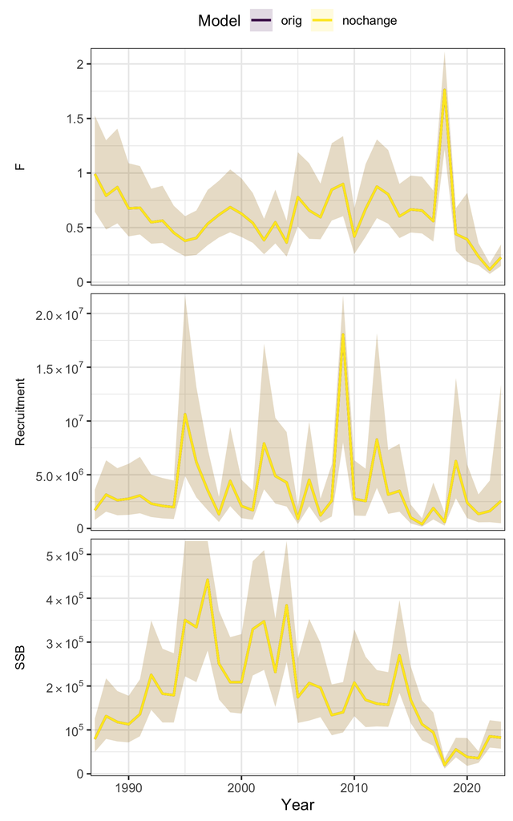

```r
knitr::include_graphics(here::here("WHAMfits/mm192_nochange/compare_png/compare_SSB_F_R.png"))
```

New explore environmental covariate (ecov) options. What format does the input need?

Following https://timjmiller.github.io/wham/articles/ex2_CPI_recruitment.html columns Year, Index, Index_sigma

We are testing indices of bottom-up recruitment impacts–food for larvae, postlarvae, and juveniles

Format ecov indices; we’ll try at least 3 variants:

- Spring large copepods (food for postlarvae and juveniles, series tested in boosted regression tree)
- Fall small copepods (food for larvae, series tested in boosted regression tree)
- Sep-Feb small copepods in herring larval area (food for larvae, new series not tested in boosted regression tree but developed to better match timing and area of herring larvae)

The code in WHAMinputs.R was used to create csv files of the VAST derives zooplankton indices. Files are saved in the WHAMfits folder.

## Spring large copepods covariate

Start with spring large copepods. Following the suggestions in [WHAM vignette 2](https://timjmiller.github.io/wham/articles/ex2_CPI_recruitment.html):

OK thats outmoded. Can just add an ecov object to existing input using `set_ecov`:

```r
config <- "largecope"

# name the model directory
name <- paste0("mm192_", config)

write.dir <- here::here(sprintf("WHAMfits/%s/", name))

if(!dir.exists(write.dir)) {
  dir.create(write.dir)
}

mm192mod <- readRDS(here::here("WHAMfits/mm192/mm192_meanrecpar.rds"))

input <- mm192mod$input

# asapdat<- read_asap3_dat(here::here("WHAMfits/mm192/Run2_87.DAT"))
#
# asap3 <- input$asap3

env.dat <- read.csv(here::here("WHAMfits/springlargecopeindex.csv"), header=T)

# make it the same length as model ?
#env.dat <- env.dat[env.dat$Time > 1986,]

# test a single ecov setup with no effect first
ecov_on <- list(
    label = "lgCopeSpr",
    mean = as.matrix(env.dat$her_sp_Estimate/1000000),
    logsigma = as.matrix(log(env.dat$her_sp_SE/1000000)), #"est_1",
    year = env.dat$Time,
    use_obs = matrix(1, ncol=1, nrow=dim(env.dat)[1]), # use all obs (all = 1)
    lag = 0, # postlarval and juvenile food in year t affects recruitment in year t
    process_model = "ar1", # "rw" or "ar1"
    #where = "recruit",
    recruitment_how = as.matrix("controlling-lag-0-linear")) # 0 = no effect, 1 = controlling, 2 = limiting

# modify current model input call adding ecov list
#input$call

ecovinput <- set_ecov(input, ecov=ecov_on)

# ecovinput <- prepare_wham_input(asap3 = asapdat, # correct structurr, asap3 is wrong structure
#                                 model_name = "test", #df.mods[m, "Model"],
#                                 ecov = ecov,
#                                 recruit_model = 2,
#                                 selectivity = list(fix_pars = list(7:8,
#                                                                    2,
#                                                                    c(1:2, 4:8),
#                                                                    1:8,
#                                                                    c(1, 3:8),
#                                                                    NULL,
#                                                                    c(1, 4:8),
#                                                                    NULL)),
#                                 M = list(re_model = as.matrix("none")), #as.matrix(df.mods[m, "M_re"])),
#                                 NAA_re = list(sigma = "rec+1",
#                                               cor = "ar1_a", #df.mods[m, "naa_cor"],
#                                               N1_model = "age-specific-fe", #init_Nnum[m],
#                                               decouple_recruitment = TRUE),
#                                 age_comp = "logistic-normal-ar1-miss0",
#                                 basic_info = list(bias_correct_process = FALSE,
#                                                   bias_correct_BRPs = FALSE,
#                                                   percentSPR = 40,
#                                                   percentFXSPR = 100,
#                                                   XSPR_R_avg_yrs = 6:35,
#                                                   XSPR_R_opt = 5))

ecovon_mod <- fit_wham(ecovinput, do.osa = F)

saveRDS(ecovon_mod, file.path(write.dir, "testecovon.rds"))

plot_wham_output(mod = ecovon_mod, dir.main = file.path(write.dir))

# test a single ecov setup with no effect first
ecov_off <- list(
    label = "lgCopeSpr",
    mean = as.matrix(env.dat$her_sp_Estimate/1000000),
    logsigma = as.matrix(log(env.dat$her_sp_SE/1000000)),
    year = env.dat$Time,
    use_obs = matrix(1, ncol=1, nrow=dim(env.dat)[1]), # use all obs (all = 1)
    lag = 0, # postlarval and juvenile food in year t affects recruitment in year t
    process_model = "ar1", # "rw" or "ar1"
    #where = "recruit",
    recruitment_how = as.matrix("none")) # 0 = no effect, 1 = controlling, 2 = limiting

# modify current model input call adding ecov list
#input$call

ecovinput <- set_ecov(input, ecov=ecov_off)

mod <- fit_wham(ecovinput, do.osa = F)

saveRDS(mod, file.path(write.dir, "testecovoff.rds"))


#compare to original, not the same data
test <- compare_wham_models(mods = list("testecovoff" = mod, "testecovon" = ecovon_mod), fdir = write.dir)

saveRDS(test, file.path(write.dir, "testcompare.rds"))
```

Test run was broken until I changed units of zooplankton to millions of cells.

Now everything runs, the covariate is included, and makes no difference in the model (which looks identical to the base model so thats a plus):

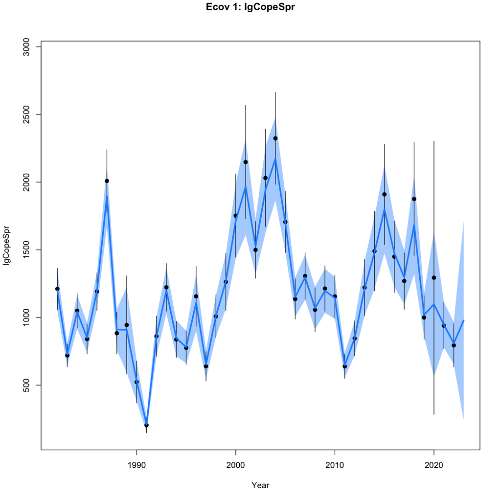

```r
testcompare <- readRDS(here::here("WHAMfits/mm192_largecope/testcompare.rds"))

knitr::include_graphics(here::here("WHAMfits/mm192_largecope/plots_png/results/Ecov_1_lgCopeSpr.png"))
```

```r
testcompare$tab
```

```
##             dAIC     AIC  rho_R rho_SSB rho_Fbar
## testecovoff  0.0 -2759.1 0.8682  0.5901  -0.2314
## testecovon   0.4 -2758.7 0.9081  0.5920  -0.2379
```

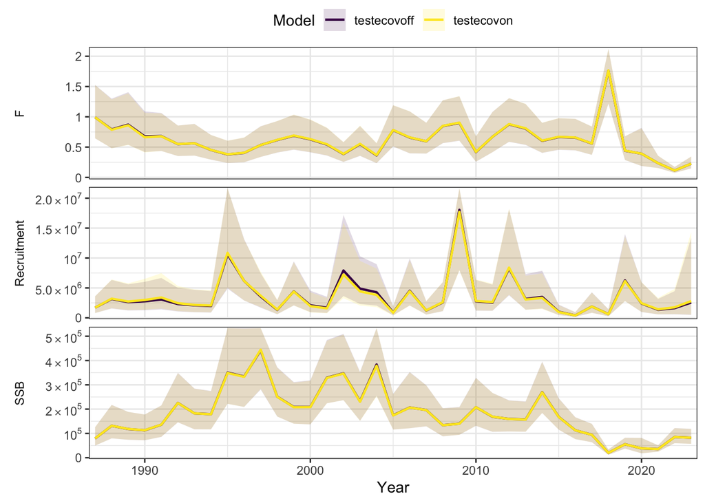

```r
testcompare$g[[1]]
```

Lets try a suite of models with the same recruitment process but different ways the large copepod series relates to it.

We’ll look at both random walk “rw” and AR1 “ar1” processes for the environmental covariate.

We’ll set the parameter `recruitment_how` as one of the following: {= “none”}{no effect.} {= “controlling”}{pre-recruit density-independent mortality.} {= “limiting”}{ maximum recruitment, e.g. ecov determines amount of suitable habitat)} {= “lethal”}{threshold, i.e. R –> 0 at some ecov value.} {= “masking”}{metabolic/growth, decreases dR/dS}

{= “directive”}{e.g. behavioral}

Going to try “none”, “controlling”, “limiting”, and “masking” (note that “masking” didn’t work well in the state space RTA simulations).

```r
config <- "largecope"

# name the model directory
name <- paste0("mm192_", config)

write.dir <- here::here(sprintf("WHAMfits/%s/", name))

if(!dir.exists(write.dir)) {
  dir.create(write.dir)
}

mm192mod <- readRDS(here::here("WHAMfits/mm192/mm192_meanrecpar.rds"))

input <- mm192mod$input

# asapdat<- read_asap3_dat(here::here("WHAMfits/mm192/Run2_87.DAT"))
#
# asap3 <- input$asap3

env.dat <- read.csv(here::here("WHAMfits/springlargecopeindex.csv"), header=T)


# larger set of ecov setups to compare
df.mods <- data.frame(Recruitment = c(rep(c(2,2,3,3), 2)),
                      ecov_process = c(rep("rw",4),rep("ar1",4)),
                      ecov_how = rep(c("none",
                                       "controlling-lag-0-linear",
                                       "limiting-lag-0-linear",
                                       "masking-lag-0-linear"),2), stringsAsFactors=FALSE)
n.mods <- dim(df.mods)[1]
df.mods$Model <- paste0("m",1:n.mods)
df.mods <- dplyr::select(df.mods, Model, tidyselect::everything()) # moves Model to first col

for(m in 5:n.mods){

  ecov <- list(
    label = "lgCopeSpr",
    mean = as.matrix(env.dat$her_sp_Estimate/1000000),
    logsigma = as.matrix(log(env.dat$her_sp_SE/1000000)),
    year = env.dat$Time,
    use_obs = matrix(1, ncol=1, nrow=dim(env.dat)[1]), # use all obs (all = 1)
    #lag = 0, # postlarval and juvenile food in year t affects recruitment in year t
    process_model = df.mods$ecov_process[m],  # "rw" or "ar1"
    #where = c("recruit")[as.logical(df.mods$ecov_how[m])+1],
    recruitment_how = as.matrix(df.mods$ecov_how[m])
    ) # 0 = no effect, 1 = controlling, 2 = limiting

  input$data$recruit_model <- df.mods$Recruitment[m]
  input$options$basic_info$recruit_model <- df.mods$Recruitment[m]

  ecovinput <- set_ecov(input, ecov=ecov)

  mod <- fit_wham(ecovinput, do.osa = T)

  # Save model
  saveRDS(mod, file.path(write.dir, paste0(df.mods$Model[m],".rds")))

  # Plot output in new subfolder
  plot_wham_output(mod=mod, dir.main=file.path(write.dir,df.mods$Model[m]), out.type='html')

}
```

Check all for convergence (from https://timjmiller.github.io/wham/articles/ex2_CPI_recruitment.html)

```r
config <- "largecope"

# name the model directory
name <- paste0("mm192_", config)

write.dir <- here::here(sprintf("WHAMfits/%s/", name))

# need this for html to work because block above running model not evaluated on knit
df.mods <- data.frame(Recruitment = c(rep(c(2,2,3,3), 2)),
                      ecov_process = c(rep("rw",4),rep("ar1",4)),
                      recruitment_how = rep(c("none",
                                       "controlling-lag-0-linear",
                                       "limiting-lag-0-linear",
                                       "masking-lag-0-linear"),2), stringsAsFactors=FALSE)
n.mods <- dim(df.mods)[1]
df.mods$Model <- paste0("m",1:n.mods)
df.mods <- dplyr::select(df.mods, Model, tidyselect::everything()) # moves Model to first col


mod.list <- paste0(write.dir, df.mods$Model,".rds")
mods <- lapply(mod.list, readRDS)

n.mods <- length(mod.list)

vign2_conv <- lapply(mods, function(x) capture.output(check_convergence(x)))
for(m in 1:n.mods) cat(paste0("Model ",m,":"), vign2_conv[[m]], "", sep='\n')
```

```
## Model 1:
## stats:nlminb thinks the model has converged: mod$opt$convergence == 0
## Maximum gradient component: 7.31e-12
## Max gradient parameter: log_NAA_sigma
## TMB:sdreport() was performed successfully for this model
##
## Model 2:
## stats:nlminb thinks the model has converged: mod$opt$convergence == 0
## Maximum gradient component: 4.47e-03
## Max gradient parameter: logit_q
## TMB:sdreport() was performed successfully for this model
##
## Model 3:
## stats:nlminb thinks the model has converged: mod$opt$convergence == 0
## Maximum gradient component: 4.96e-03
## Max gradient parameter: log_NAA_sigma
## TMB:sdreport() was performed successfully for this model
##
## Model 4:
## stats:nlminb thinks the model has NOT converged: mod$opt$convergence != 0
## Maximum gradient component: 5.38e+07
## Max gradient parameter: Ecov_beta_R
## TMB:sdreport() was performed for this model, but it appears hessian was not invertible
##
## Model 5:
## stats:nlminb thinks the model has converged: mod$opt$convergence == 0
## Maximum gradient component: 9.33e-12
## Max gradient parameter: log_NAA_sigma
## TMB:sdreport() was performed successfully for this model
##
## Model 6:
## stats:nlminb thinks the model has converged: mod$opt$convergence == 0
## Maximum gradient component: 2.37e-03
## Max gradient parameter: Ecov_beta_R
## TMB:sdreport() was performed successfully for this model
##
## Model 7:
## stats:nlminb thinks the model has converged: mod$opt$convergence == 0
## Maximum gradient component: 1.88e-02
## Max gradient parameter: log_NAA_sigma
## TMB:sdreport() was performed successfully for this model
##
## Model 8:
## stats:nlminb thinks the model has converged: mod$opt$convergence == 0
## Maximum gradient component: 2.62e-03
## Max gradient parameter: Ecov_beta_R
## TMB:sdreport() was performed successfully for this model
```

Compare models (from https://timjmiller.github.io/wham/articles/ex2_CPI_recruitment.html)

```r
opt_conv = 1-sapply(mods, function(x) x$opt$convergence)
ok_sdrep = sapply(mods, function(x) if(x$na_sdrep==FALSE & !is.na(x$na_sdrep)) 1 else 0)
df.mods$conv <- as.logical(opt_conv)
df.mods$pdHess <- as.logical(ok_sdrep)
df.mods$NLL <- sapply(mods, function(x) round(x$opt$objective,3))

not_conv <- !df.mods$conv | !df.mods$pdHess
mods2 <- mods
mods2[not_conv] <- NULL
df.aic.tmp <- as.data.frame(compare_wham_models(mods2, table.opts=list(sort=FALSE, calc.rho=T))$tab)
```

```
##    dAIC     AIC  rho_R rho_SSB rho_Fbar
## m1  3.7 -2755.4 0.8594  0.5907  -0.2362
## m2  4.3 -2754.8 0.8104  0.5940  -0.2448
## m3  4.3 -2754.8 0.8162  0.6011  -0.2446
## m4  0.0 -2759.1 0.8682  0.5901  -0.2314
## m5  0.4 -2758.7 0.9081  0.5920  -0.2379
## m6  0.4 -2758.7 0.5715  0.5914  -0.2399
## m7  1.9 -2757.2 0.8908  0.5945  -0.2374
```

```r
df.aic <- df.aic.tmp[FALSE,]
ct = 1
for(i in 1:n.mods){
  if(not_conv[i]){
    df.aic[i,] <- rep(NA,5)
  } else {
    df.aic[i,] <- df.aic.tmp[ct,]
    ct <- ct + 1
  }
}
df.mods <- cbind(df.mods, df.aic)
df.mods <- df.mods[order(df.mods$dAIC, na.last=TRUE),]
df.mods[is.na(df.mods$AIC), c('dAIC','AIC','rho_R','rho_SSB','rho_Fbar')] <- "---"
rownames(df.mods) <- NULL

df.mods
```

```
##   Model Recruitment ecov_process          recruitment_how  conv pdHess
## 1    m5           2          ar1                     none  TRUE   TRUE
## 2    m6           2          ar1 controlling-lag-0-linear  TRUE   TRUE
## 3    m7           3          ar1    limiting-lag-0-linear  TRUE   TRUE
## 4    m8           3          ar1     masking-lag-0-linear  TRUE   TRUE
## 5    m1           2           rw                     none  TRUE   TRUE
## 6    m2           2           rw controlling-lag-0-linear  TRUE   TRUE
## 7    m3           3           rw    limiting-lag-0-linear  TRUE   TRUE
## 8    m4           3           rw     masking-lag-0-linear FALSE  FALSE
##         NLL dAIC     AIC  rho_R rho_SSB rho_Fbar
## 1 -1509.570    0 -2759.1 0.8682  0.5901  -0.2314
## 2 -1510.349  0.4 -2758.7 0.9081   0.592  -0.2379
## 3 -1510.349  0.4 -2758.7 0.5715  0.5914  -0.2399
## 4 -1509.592  1.9 -2757.2 0.8908  0.5945  -0.2374
## 5 -1506.709  3.7 -2755.4 0.8594  0.5907  -0.2362
## 6 -1507.424  4.3 -2754.8 0.8104   0.594  -0.2448
## 7 -1507.424  4.3 -2754.8 0.8162  0.6011  -0.2446
## 8 -1175.320  ---     ---    ---     ---      ---
```

Outputs are nearly identical for SSB and F, but there are small differences in status determination.

*The numbers in the plots are not the model numbers! They are in order by the first table above*

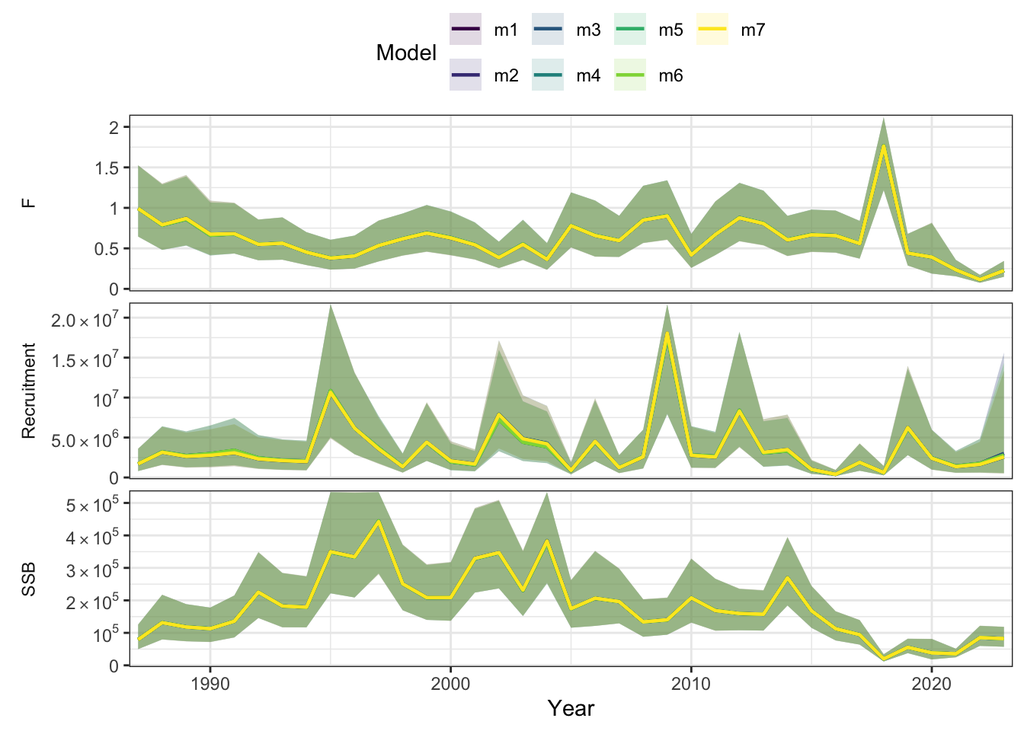

```r
lgcope1 <- compare_wham_models(mods2, do.table= FALSE, fdir = write.dir)

saveRDS(lgcope1, file.path(write.dir, "lgcope1compare.rds"))

lgcope1$g[[1]]
```

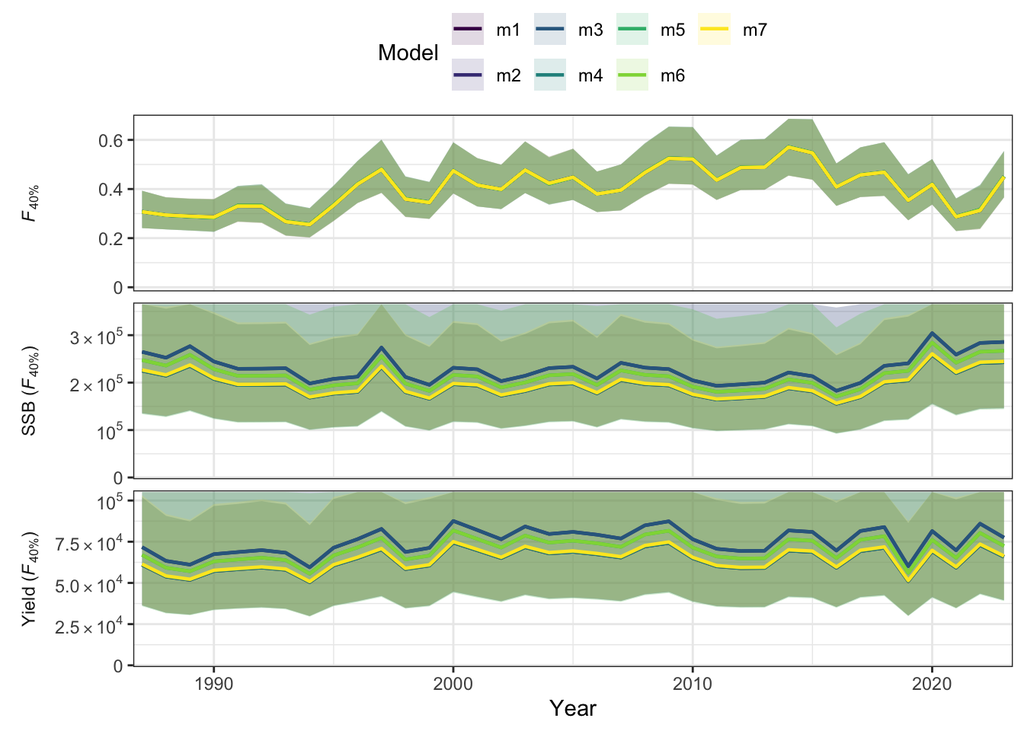

```r
lgcope1$g[[8]]
```

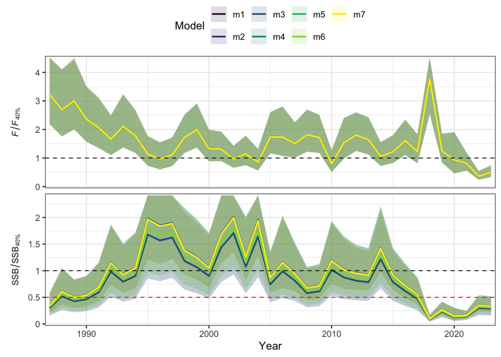

```r
lgcope1$g[[9]]
```

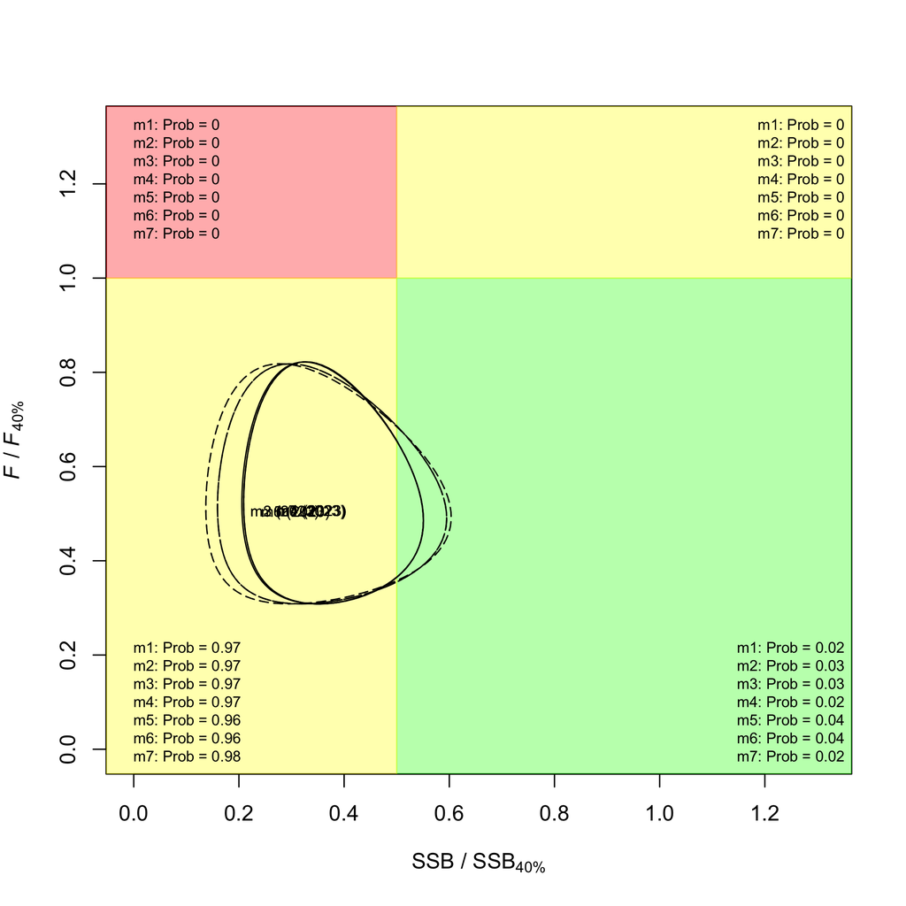

```r
knitr::include_graphics(here::here(write.dir, "compare_png/compare_rel_status_kobe.png"))
```

## Fall small copepods covariate

## Sept-Feb small copepods in larval area covariate